# ngsReports: Default FastQC Summary Report

/hpcfs/users/a1647910/20200910_Hypoxia/0_rawData/FastQC

10 September, 2020

# FastQC Summary

| Filename | Total | Flagged As Poor Quality | Sequence Length | %GC | File Type | Encoding |
| --- | --- | --- | --- | --- | --- | --- |
| 1-MORGAN-6P-PN1_S2_R1_001.fastq.gz | 26302897 | 0 | 76-76 | 0.44 | Conventional base calls | Sanger / Illumina 1.9 |
| 10-MORGAN-6P-PH2_S9_R1_001.fastq.gz | 30104052 | 0 | 76-76 | 0.43 | Conventional base calls | Sanger / Illumina 1.9 |
| 11-MORGAN-6P-PH3_S1_R1_001.fastq.gz | 48869955 | 0 | 76-76 | 0.43 | Conventional base calls | Sanger / Illumina 1.9 |
| 12-MORGAN-6P-PH4_S2_R1_001.fastq.gz | 36665915 | 0 | 76-76 | 0.42 | Conventional base calls | Sanger / Illumina 1.9 |
| 2-MORGAN-6P-PN2_S5_R1_001.fastq.gz | 45259313 | 0 | 76-76 | 0.44 | Conventional base calls | Sanger / Illumina 1.9 |
| 3-MORGAN-6P-PN3_S10_R1_001.fastq.gz | 29287775 | 0 | 76-76 | 0.44 | Conventional base calls | Sanger / Illumina 1.9 |
| 4-MORGAN-6P-PN4_S8_R1_001.fastq.gz | 32052087 | 0 | 76-76 | 0.43 | Conventional base calls | Sanger / Illumina 1.9 |
| 9-MORGAN-6P-PH1_S7_R1_001.fastq.gz | 30645100 | 0 | 76-76 | 0.43 | Conventional base calls | Sanger / Illumina 1.9 |

## Read Totals

Library Sizes ranged between *26,302,897* and *48,869,955* reads.

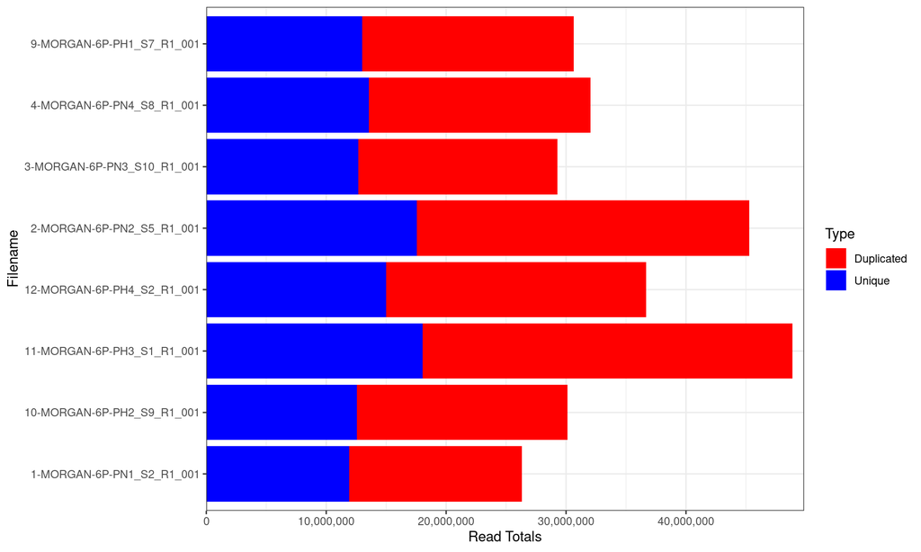

Read totals for each library. Duplicated reads are conventionally an high overestimate at this point.

## FastQC Summary

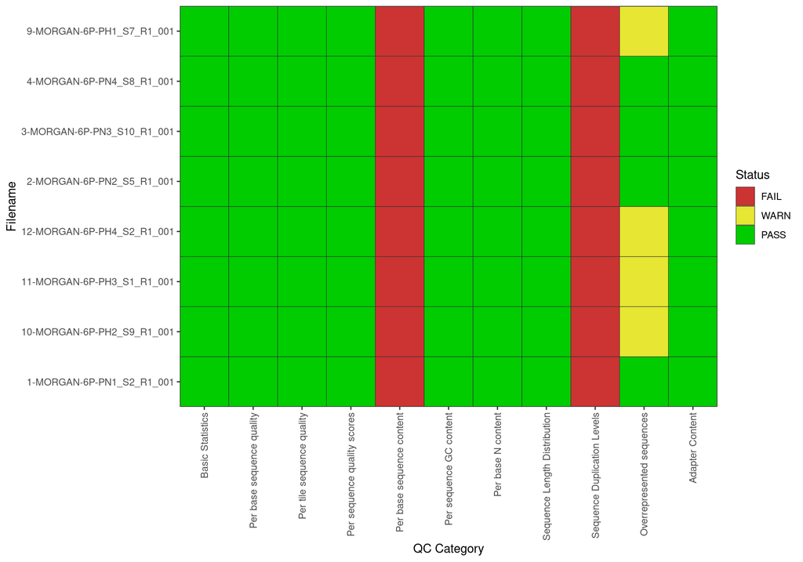

Summary of FastQC flags for each parameter

## Per Base Sequence Quality

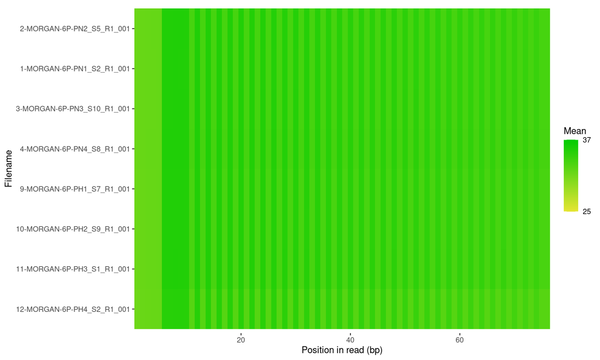

Heatmap showing mean base qualities for each library

## Per Sequence Quality Scores

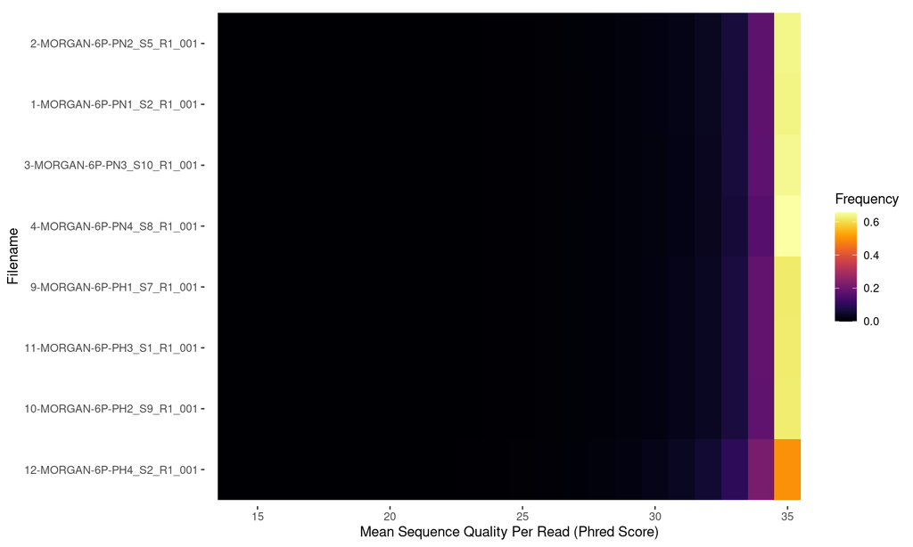

Heatmap showing mean sequence qualities for each library

## Per Base Sequence Content

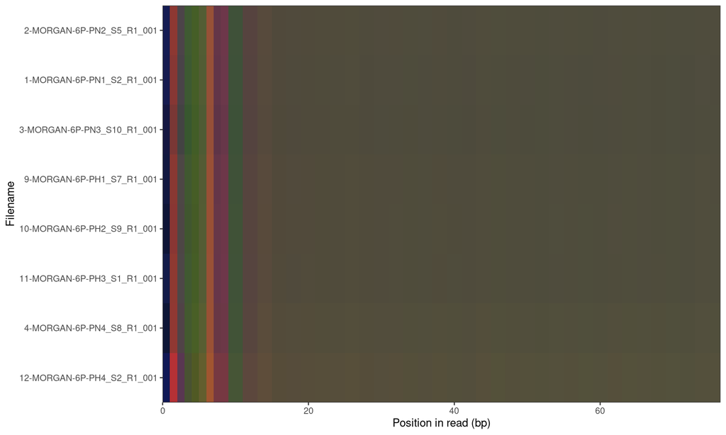

Heatmap of summed base distributions along each read

## Per Sequence GC Content

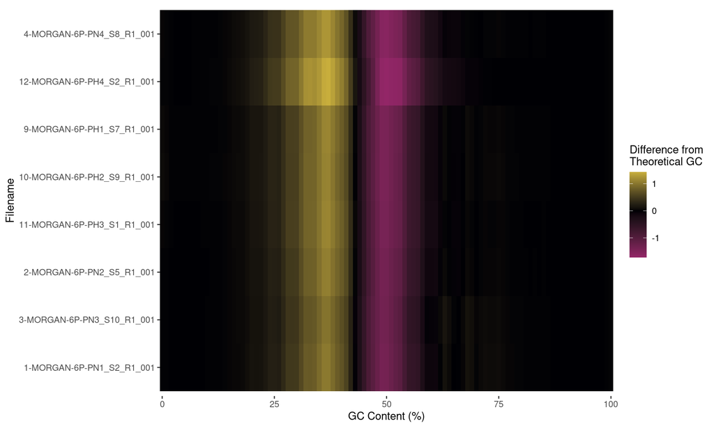

GC Content Heatmap normalised to theoretical GC content in the Drerio Transcriptome

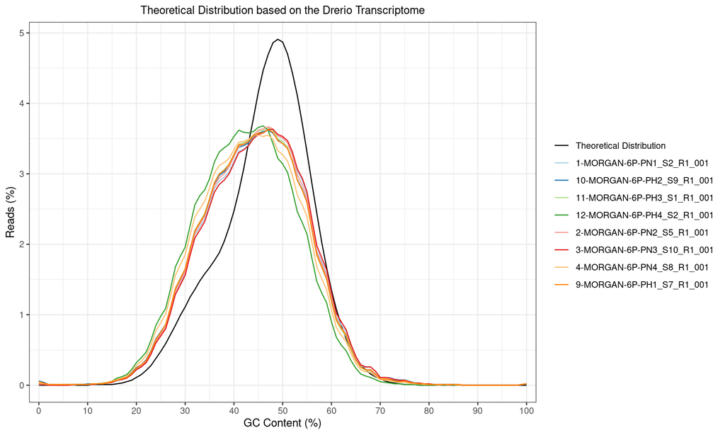

GC Content Distributions for all reads showing theoretical GC content from the Drerio Transcriptome

## Sequence Length Distribution

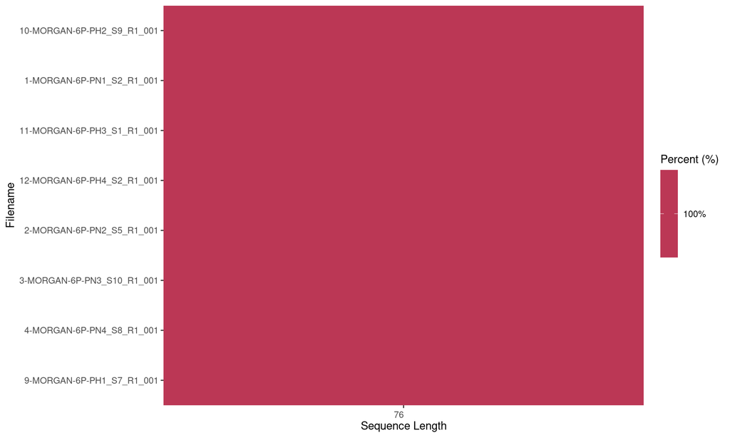

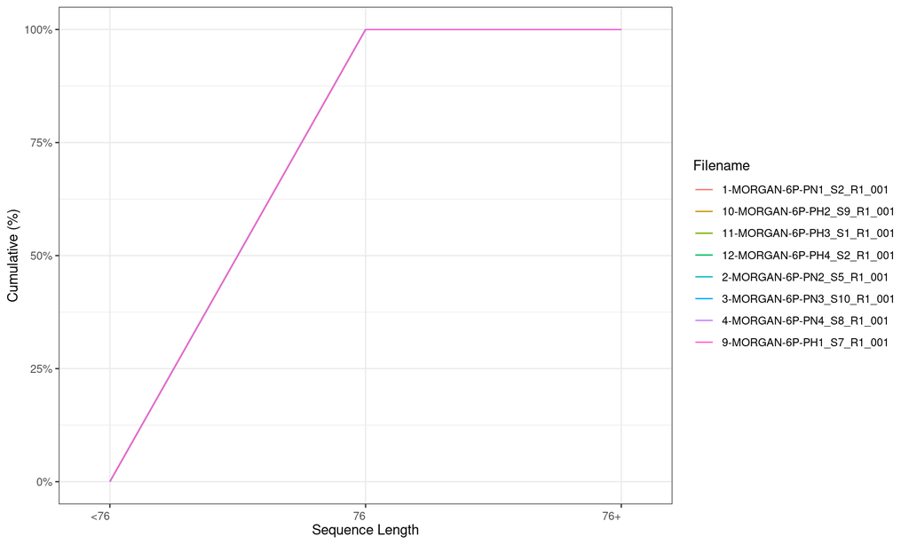

## Sequence Duplication Levels

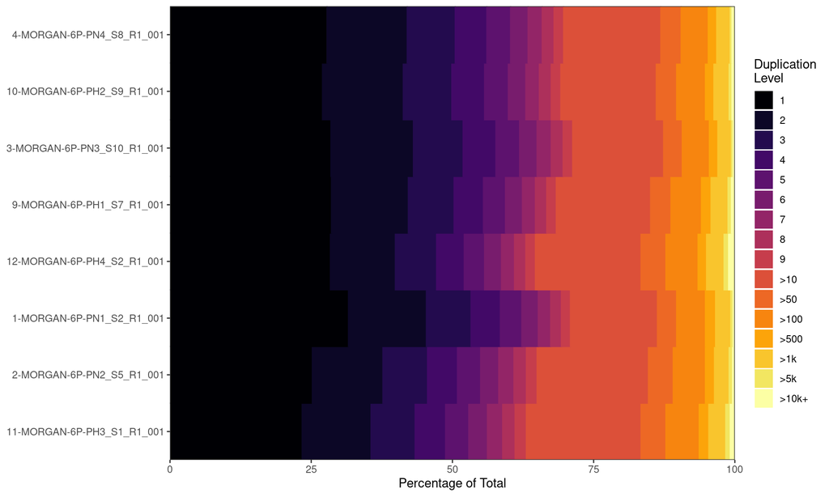

## Adapter Content

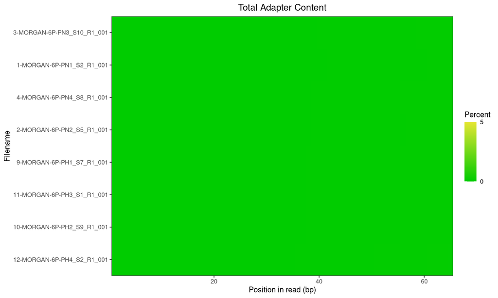

Universal Adapter Content

## Overrepresented Summary

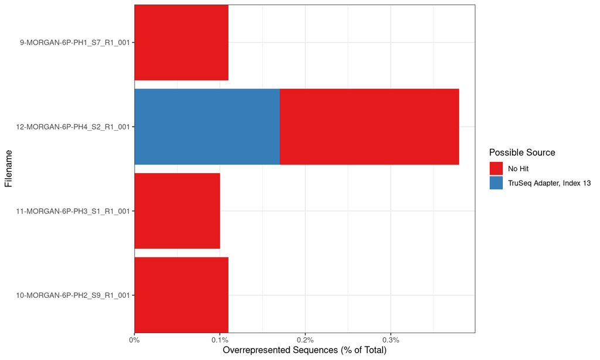

Total overrepresented sequences for each library

## Overrepresented Sequences

```
## Overrepresented_sequences missing from 1-MORGAN-6P-PN1_S2_R1_001.fastq.gz
```

```
## Overrepresented_sequences missing from 2-MORGAN-6P-PN2_S5_R1_001.fastq.gz
```

```
## Overrepresented_sequences missing from 3-MORGAN-6P-PN3_S10_R1_001.fastq.gz
```

```
## Overrepresented_sequences missing from 4-MORGAN-6P-PN4_S8_R1_001.fastq.gz
```

| Sequence | Total | Present In | % Across All Files | Max Individual % | Possible Source |
| --- | --- | --- | --- | --- | --- |
| CTCAAATGTGTGGTAGGGGGGAGGGCAGCCGTGTAATCATTCTACATTTG | 90686 | 2 | 0.000324821605113308 | 0.00107464930303798 | No Hit |
| TTTTTTTTTTTTTTTTTTTTTTTTTTTTTTTTTTTTTTTTTTTTTTTTTT | 66872 | 2 | 0.000239523965960977 | 0.00114472961978673 | No Hit |
| GATCGGAAGAGCACACGTCTGAACTCCAGTCACAGTCAAATCTCGTATGC | 61501 | 1 | 0.00022028597066883 | 0.0016773343853549 | TruSeq Adapter, Index 13 (98% over 50bp) |
| ATTAATTTCATCTATAAGGTATAAAATTCGAAGTGATGGTAAAGCAATCA | 38742 | 1 | 0.00013876715948768 | 0.00105662166074405 | No Hit |

# Session Information

**R version 4.0.2 (2020-06-22)**

**Platform:** x86_64-pc-linux-gnu (64-bit)

**locale:** *LC_CTYPE=en_AU.UTF-8*, *LC_NUMERIC=C*, *LC_TIME=en_AU.UTF-8*, *LC_COLLATE=en_AU.UTF-8*, *LC_MONETARY=en_AU.UTF-8*, *LC_MESSAGES=en_AU.UTF-8*, *LC_PAPER=en_AU.UTF-8*, *LC_NAME=C*, *LC_ADDRESS=C*, *LC_TELEPHONE=C*, *LC_MEASUREMENT=en_AU.UTF-8* and *LC_IDENTIFICATION=C*

**attached base packages:** *parallel*, *stats*, *graphics*, *grDevices*, *utils*, *datasets*, *methods* and *base*

**other attached packages:** *pander(v.0.6.3)*, *DT(v.0.14)*, *scales(v.1.1.1)*, *readr(v.1.3.1)*, *dplyr(v.1.0.0)*, *stringr(v.1.4.0)*, *magrittr(v.1.5)*, *ngsReports(v.1.4.2)*, *tibble(v.3.0.3)*, *ggplot2(v.3.3.2)* and *BiocGenerics(v.0.34.0)*

**loaded via a namespace (and not attached):** *Biobase(v.2.48.0)*, *ggdendro(v.0.1-20)*, *httr(v.1.4.1)*, *tidyr(v.1.1.0)*, *jsonlite(v.1.7.0)*, *viridisLite(v.0.3.0)*, *highr(v.0.8)*, *stats4(v.4.0.2)*, *latticeExtra(v.0.6-29)*, *GenomeInfoDbData(v.1.2.3)*, *Rsamtools(v.2.4.0)*, *yaml(v.2.2.1)*, *ggrepel(v.0.8.2)*, *pillar(v.1.4.6)*, *lattice(v.0.20-41)*, *glue(v.1.4.1)*, *digest(v.0.6.25)*, *GenomicRanges(v.1.40.0)*, *RColorBrewer(v.1.1-2)*, *XVector(v.0.28.0)*, *colorspace(v.1.4-1)*, *htmltools(v.0.5.0)*, *Matrix(v.1.2-18)*, *plyr(v.1.8.6)*, *FactoMineR(v.2.3)*, *pkgconfig(v.2.0.3)*, *ShortRead(v.1.46.0)*, *zlibbioc(v.1.34.0)*, *purrr(v.0.3.4)*, *jpeg(v.0.1-8.1)*, *BiocParallel(v.1.22.0)*, *farver(v.2.0.3)*, *generics(v.0.0.2)*, *IRanges(v.2.22.2)*, *ellipsis(v.0.3.1)*, *withr(v.2.2.0)*, *SummarizedExperiment(v.1.18.2)*, *lazyeval(v.0.2.2)*, *crayon(v.1.3.4)*, *evaluate(v.0.14)*, *MASS(v.7.3-52)*, *forcats(v.0.5.0)*, *hwriter(v.1.3.2)*, *truncnorm(v.1.0-8)*, *Cairo(v.1.5-12.2)*, *tools(v.4.0.2)*, *data.table(v.1.12.8)*, *hms(v.0.5.3)*, *lifecycle(v.0.2.0)*, *matrixStats(v.0.56.0)*, *plotly(v.4.9.2.1)*, *S4Vectors(v.0.26.1)*, *munsell(v.0.5.0)*, *cluster(v.2.1.0)*, *DelayedArray(v.0.14.1)*, *Biostrings(v.2.56.0)*, *flashClust(v.1.01-2)*, *compiler(v.4.0.2)*, *GenomeInfoDb(v.1.24.2)*, *rlang(v.0.4.7)*, *grid(v.4.0.2)*, *RCurl(v.1.98-1.2)*, *rstudioapi(v.0.11)*, *htmlwidgets(v.1.5.1)*, *crosstalk(v.1.1.0.1)*, *leaps(v.3.1)*, *labeling(v.0.3)*, *bitops(v.1.0-6)*, *rmarkdown(v.2.3)*, *gtable(v.0.3.0)*, *reshape2(v.1.4.4)*, *R6(v.2.4.1)*, *GenomicAlignments(v.1.24.0)*, *zoo(v.1.8-8)*, *lubridate(v.1.7.9)*, *knitr(v.1.29)*, *stringi(v.1.4.6)*, *Rcpp(v.1.0.5)*, *vctrs(v.0.3.2)*, *png(v.0.1-7)*, *scatterplot3d(v.0.3-41)*, *tidyselect(v.1.1.0)* and *xfun(v.0.15)*